# Tuolumne River

Sadie Gill, Mark Tompkins

July 2020

## Future Data Improvement

Instream habitat suitability relationships provided for the Voluntary Agreement process.

## Instream Spawning and Rearing Habitat

**Data Source:** [Final Lower Tuolumne Instream Flow Study Report](https://s3-us-west-2.amazonaws.com/cvpiahabitat-r-package/cvpia-sit-model-inputs/Stillwater2010_Tuolumne_P-2299-075_71_DP_FLA_AttC_StudyRept_IFIM_AppA-H_140428.pdf) (pg. 108-109)

The instream spawning and rearing habitat for Fall Run Chinook Salmon and Steelhead in the Tuolumne River are based on data from a California Department of Fish and Game site-specific study. These data consist of 10 sites spread over 9.2 miles of the dominant spawning reach of the Lower Tuolumne River. They were reviewed by Stillwater Sciences for use in their 2014 Flo2D model. The weighted usable area (WUA) results for Salmon and Steelhead are provided in tables H-1 and H-2 on pages 108-109 of the Final Lower Tuolumne Instream Flow Study Report. The instream spawning and rearing habitat data were provided to us by Mark Gard from the California Department of Fish and Wildlife in a [spreadsheet](https://cvpiahabitat-r-package.s3-us-west-2.amazonaws.com/IFIMWUA.xlsx). Mark Gard instructed us to use cells A2:H32 in the ‘Tuolumne’ tab within the spreadsheet.

### Combine Spawning and Rearing Data

The instream spawning and rearing habitat data described above for Fall Run Chinook Salmon (FR) and Steelhead (ST) are combined for use in the Decision Support Model (DSM) in the following format. Units are in square feet per 1000 feet.

Header Descriptions: flow_cfs = flow in cubic feet per second, FR_spawn_wua = Fall Run Chinook Spawning WUA, FR_fry_wua = Fall Run Chinook fry WUA, FR_juv_wua = Fall Run Chinook Juvenile WUA, ST_spawn_wua = Steelhead Spawning WUA, ST_fry_wua = Steelhead fry WUA, ST_juv_wua = Steelhead Juvenile WUA, ST_adult_wua = Steelhead Adult WUA, watershed = section of stream modeled for CVPIA SDM

| flow_cfs | FR_spawn_wua | FR_fry_wua | FR_juv_wua | ST_spawn_wua | ST_fry_wua | ST_juv_wua | ST_adult_wua | watershed |
| --- | --- | --- | --- | --- | --- | --- | --- | --- |
| 50 | 2116.32 | 32897.03 | 48648.28 | 11648.21 | 54751.06 | 53029.98 | 15204.23 | Tuolumne River |
| 75 | 4950.27 | 30762.01 | 50596.55 | 17137.87 | 50438.41 | 55934.07 | 20427.83 | Tuolumne River |
| 100 | 7447.46 | 28799.02 | 51759.16 | 21449.10 | 46884.87 | 57493.70 | 24811.70 | Tuolumne River |
| 125 | 10807.84 | 27025.69 | 52516.33 | 24938.94 | 44259.05 | 58459.15 | 28513.29 | Tuolumne River |
| 150 | 13071.88 | 25415.04 | 52814.11 | 27813.79 | 42362.45 | 58803.13 | 31455.03 | Tuolumne River |

*… with 25 more rows*

### Spawning WUA

The following plot shows the spawning WUA in square feet per thousand feet for Fall Run Chinook Salmon and Steelhead. These area per length rates are multiplied by the total spawning reach length mapped by the Science Integration Team (SIT) to estimate available habitat.

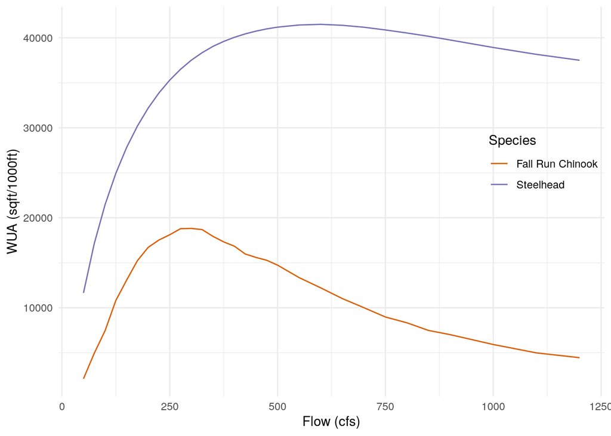

### Rearing WUA

The following plot shows the rearing WUA in square feet per thousand feet for Fall Run Chinook Salmon and Steelhead fry and juvenile. These rates are multiplied by the total rearing reach length mapped by the SIT to estimate available habitat.

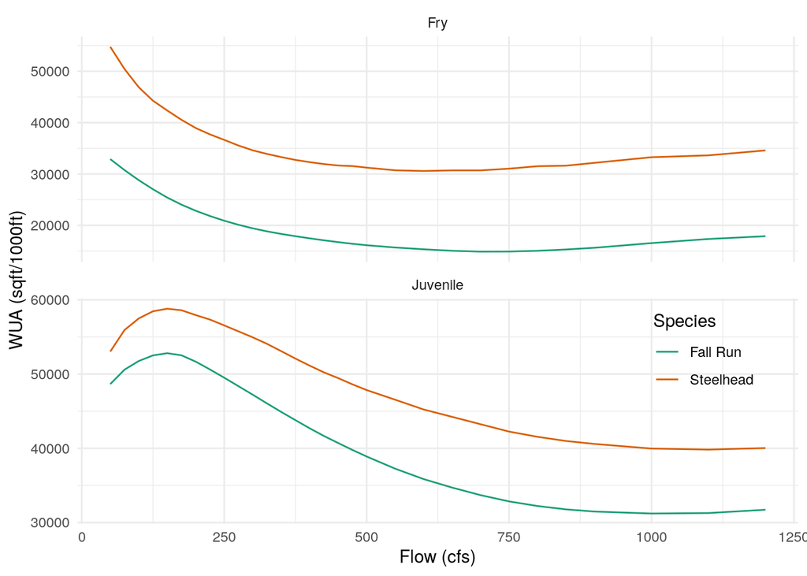

## Floodplain Rearing Habitat

**Data Source:** [TUFLOW hydraulic model with 1D channel and 2D overbank components](https://s3-us-west-2.amazonaws.com/cvpiahabitat-r-package/cvpia-sit-model-inputs/Tuolumne_W-AR_21__Study+Report.pdf)

The entire mapped rearing extent of 54.33 miles was modeled by TID and MID using a TUFLOW hydraulic model with 1D channel and 2D overbank components. This approach directly modeled inundated floodplain area.

## Floodplain Data

The areas represent total inundated area in acres.

Header Descriptions: flow_cfs = flow in cubic feet per second, FR_floodplain_acres = Fall Run Chinook floodplain acres, SR_floodplain_acres = Spring Run Chinook floodplain acres, ST_floodplain_acres = Steelhead floodplain acres, watershed = section of stream modeled for CVPIA SDM

| flow_cfs | FR_floodplain_acres | SR_floodplain_acres | ST_floodplain_acres | watershed |
| --- | --- | --- | --- | --- |
| 1000 | 0.00000 | 0.00000 | 0.00000 | Tuolumne River |
| 1250 | 35.96074 | 35.96074 | 35.96074 | Tuolumne River |
| 1500 | 76.67872 | 76.67872 | 76.67872 | Tuolumne River |
| 1750 | 116.87500 | 116.87500 | 116.87500 | Tuolumne River |
| 2000 | 156.85950 | 156.85950 | 156.85950 | Tuolumne River |

*… with 28 more rows*

## Floodplain Plot

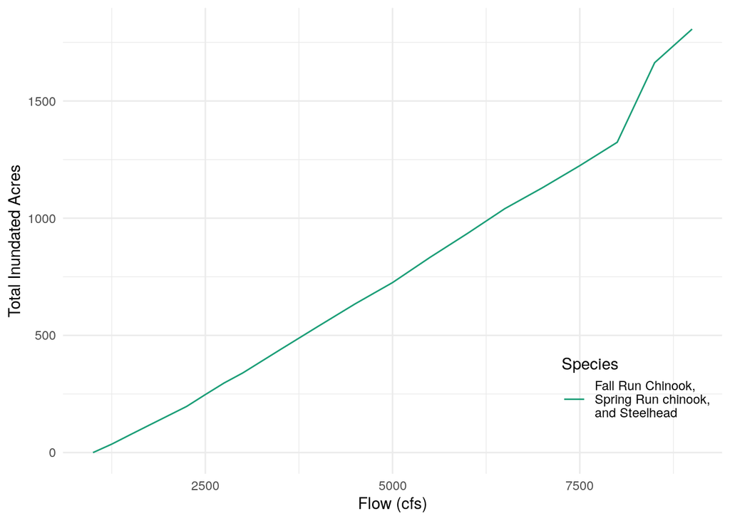